# Who leaves, and why? People analytics in R

Rita Moreira

November 2026

**About the data.** This report uses IBM’s *HR Analytics Employee Attrition* sample: 1,470 **fictional** employees created by IBM data scientists. No real company or person is described. I use it to show the method end to end in R; the numbers illustrate, they do not describe a real workforce. All code is folded under the **Code** buttons, and the same script produces the data behind the interactive version on my site.

## Key findings

**About 1 in 6 employees left**16.1% of employees (237 of 1,470) left the company.

**Overtime is the sharpest single divider**31% of overtime workers left vs 10% of everyone else (2.9×). Holding the other factors constant, overtime multiplies the odds of leaving by 5.9 (95% CI 4.2–8.5).

**Exits cluster in the first two years**35% of employees in their first two years left, vs 11% at 5–9 years and 10% at 10+. At these rates a new hire has a 64% chance of completing year 1 and 42% of completing year 2 (Kaplan-Meier, delayed entry).

**Overtime workers leave sooner at every tenure**At the same tenure, overtime workers leave at 3.4× the rate of others (Cox hazard ratio, 95% CI 2.6–4.5; log-rank p < 0.001). In their first two years, 55% of overtime workers left vs 25% of the rest.

**Junior staff without equity are the most exposed**Job level 1: 26% leave vs 10% at level 2+. No stock options: 24% vs 10% with any.

**The riskiest segment the tree finds**Overtime = Yes & Monthly income < 2,475: 70% leave (69 people, 4.3× the company average). Lowest-risk segment: Overtime = No & Total working years ≥ 3 at 8%.

**Other strong signals**Single employees: 26%. Frequent travellers: 25%. Ages 18–24: 39%. Company average: 16%.

**Risk can be ranked, imperfectly**On 441 held-out employees the model scores AUC 0.82 (overtime alone: 0.64). Flagging the riskiest 20% catches 69% of leavers, and 55% of those flagged actually left (vs 16% base rate).

**What overtime might be worth**If no one worked overtime, the model expects 154 leavers instead of 237 (83 fewer, about 65% of overtime workers’ exits). Taking half of overtime workers off overtime, highest-impact first: 65 fewer. The raw rate gap gives 84 fewer, close to the model, so the overtime effect is not explained away by who works overtime.

## 1. The question and the data

Every exit costs a company twice: the work that stops while the seat is empty, and the hiring and ramp-up of the replacement. HR leadership rarely has budget to fix everything, so the useful question is narrower: **who leaves, when, and where would retention effort pay off?**

The file has one row per employee: demographics, role and level, pay, tenure, travel, overtime, four satisfaction ratings, and whether the person left (`Attrition`). 1,470 employees, 237 leavers: an attrition rate of **16.1%**. Three columns (`EmployeeCount`, `Over18`, `StandardHours`) hold one value for everyone and are dropped. There are no missing values.

```r
suppressWarnings(suppressPackageStartupMessages({   # quiet "built under R x.y" notes
  library(dplyr)
  library(survival)
  library(broom)
  library(rpart)
  library(jsonlite)
}))

# When knitted, the Rmd defines SRC itself; from the command line, read the args.
if (!exists("SRC")) {
  args <- commandArgs(trailingOnly = TRUE)
  if (length(args) < 2) stop("Usage: Rscript people_attrition.R <ibm_attrition.csv> <out_dir>")
  SRC <- args[1]
  OUT_DIR <- args[2]
}

SEED        <- 2026                      # one seed for the train/test split
TOP_SHARE   <- 0.20                      # "flag the riskiest 20%" for the confusion matrix
OT_SHARES   <- c(0, 0.25, 0.5, 0.75, 1)  # what-if: share of overtime workers taken off overtime
KM_YEARS    <- c(1, 2, 5, 10)            # retention checkpoints
KM_MIN_RISK <- 10                        # fewer people than this at risk in a step = too thin to quote

pct <- function(x, d = 0) paste0(formatC(100 * x, format = "f", digits = d), "%")
num <- function(x) formatC(round(x), format = "d", big.mark = ",")
fmt_p <- function(p) if (p < 0.001) "< 0.001" else sprintf("= %.3f", p)
dash <- "\u2013"                          # en dash, kept as an escape so this file stays ASCII
# Read the CSV as plain data (it starts with a UTF-8 byte-order mark).
hr_raw <- read.csv(SRC, fileEncoding = "UTF-8-BOM", stringsAsFactors = FALSE)

expected_cols <- c(
  "Age", "Attrition", "BusinessTravel", "DailyRate", "Department", "DistanceFromHome",
  "Education", "EducationField", "EmployeeCount", "EmployeeNumber", "EnvironmentSatisfaction",
  "Gender", "HourlyRate", "JobInvolvement", "JobLevel", "JobRole", "JobSatisfaction",
  "MaritalStatus", "MonthlyIncome", "MonthlyRate", "NumCompaniesWorked", "Over18", "OverTime",
  "PercentSalaryHike", "PerformanceRating", "RelationshipSatisfaction", "StandardHours",
  "StockOptionLevel", "TotalWorkingYears", "TrainingTimesLastYear", "WorkLifeBalance",
  "YearsAtCompany", "YearsInCurrentRole", "YearsSinceLastPromotion", "YearsWithCurrManager")
missing_cols <- setdiff(expected_cols, names(hr_raw))
if (length(missing_cols)) stop("Missing columns: ", paste(missing_cols, collapse = ", "))
stopifnot(!anyNA(hr_raw[expected_cols]),
          all(hr_raw$Attrition %in% c("Yes", "No")),
          !anyDuplicated(hr_raw$EmployeeNumber))

# Three columns hold a single value for everyone, so they carry no information.
const_cols <- c("EmployeeCount", "Over18", "StandardHours")
stopifnot(all(vapply(hr_raw[const_cols], function(x) length(unique(x)) == 1, logical(1))))

hr <- hr_raw %>%
  select(-all_of(const_cols)) %>%
  mutate(left = as.integer(Attrition == "Yes"))

n_emp        <- nrow(hr)
n_left       <- sum(hr$left)
overall_rate <- n_left / n_emp
```

I look at the question through five lenses, each answering a different part of it:

| Lens | Question it answers | R tools |
| --- | --- | --- |
| Segment rates + chi-square | Which groups leave more? | `dplyr`, `chisq.test` |
| Logistic regression | Which factors matter once the others are held constant? | `glm`, `broom` |
| Hold-out validation | Can we rank people by risk, and how well? | rank-based AUC, calibration |
| Survival analysis | *When* in their tenure do people leave? | `survival::survfit`, `coxph` |
| Decision tree | Which combinations of traits define high-risk pockets? | `rpart` |

A what-if on top of the regression then asks how many exits overtime might account for.

## 2. Who leaves? Attrition by segment

Each variable is cut into groups and tested with a chi-square test. Cramér’s V puts the strength of association on a 0-1 scale that is comparable across variables with different numbers of groups.

```r
# Display versions of each segmenting variable (bands for the continuous ones).
rating_lab <- c("Low", "Medium", "High", "Very High")      # IBM codebook, 1-4 scales
wlb_lab    <- c("Bad", "Good", "Better", "Best")
band <- function(x, breaks, labels) cut(x, breaks = breaks, labels = labels, include.lowest = TRUE)

# Income quartiles, labelled with the actual min-max inside each quartile.
inc_q   <- cut(hr$MonthlyIncome, quantile(hr$MonthlyIncome, 0:4 / 4), include.lowest = TRUE, labels = FALSE)
inc_rng <- tapply(hr$MonthlyIncome, inc_q, range)
inc_lab <- sprintf("Q%d (%s%s%s)", 1:4,
                   vapply(inc_rng, function(r) num(r[1]), ""), dash,
                   vapply(inc_rng, function(r) num(r[2]), ""))

seg_df <- hr %>% transmute(
  left,
  OverTime                = factor(OverTime, levels = c("No", "Yes")),
  JobLevel                = factor(paste("Level", JobLevel)),
  MaritalStatus           = factor(MaritalStatus),
  BusinessTravel          = factor(BusinessTravel,
                                   levels = c("Non-Travel", "Travel_Rarely", "Travel_Frequently"),
                                   labels = c("Non-travel", "Travels rarely", "Travels frequently")),
  Department              = factor(Department),
  JobRole                 = factor(JobRole),
  AgeBand                 = band(Age, c(18, 24, 29, 34, 44, 60),
                                 paste0(c("18", "25", "30", "35", "45"), dash, c("24", "29", "34", "44", "60"))),
  TenureBand              = band(YearsAtCompany, c(0, 1, 4, 9, 40),
                                 c(paste0("0", dash, "1 yrs"), paste0("2", dash, "4 yrs"),
                                   paste0("5", dash, "9 yrs"), "10+ yrs")),
  IncomeBand              = factor(inc_lab[inc_q], levels = inc_lab),
  JobSatisfaction         = factor(JobSatisfaction, 1:4, paste(1:4, rating_lab)),
  EnvironmentSatisfaction = factor(EnvironmentSatisfaction, 1:4, paste(1:4, rating_lab)),
  WorkLifeBalance         = factor(WorkLifeBalance, 1:4, paste(1:4, wlb_lab)),
  StockOptionLevel        = factor(paste("Level", StockOptionLevel)),
  DistanceBand            = band(DistanceFromHome, c(1, 5, 10, 20, 29),
                                 paste0(c("1", "6", "11", "21"), dash, c("5", "10", "20", "29")))
)

seg_spec <- data.frame(
  key   = c("OverTime", "JobLevel", "MaritalStatus", "BusinessTravel", "Department", "JobRole",
            "AgeBand", "TenureBand", "IncomeBand", "JobSatisfaction", "EnvironmentSatisfaction",
            "WorkLifeBalance", "StockOptionLevel", "DistanceBand"),
  label = c("Overtime", "Job level", "Marital status", "Business travel", "Department", "Job role",
            "Age", "Years at company", "Monthly income (quartile)", "Job satisfaction",
            "Environment satisfaction", "Work-life balance", "Stock option level", "Distance from home"),
  kind  = c("nominal", "ordinal", "nominal", "ordinal", "nominal", "nominal",
            "ordinal", "ordinal", "ordinal", "ordinal", "ordinal",
            "ordinal", "ordinal", "ordinal"),
  stringsAsFactors = FALSE)

# Wilson 95% interval for a proportion: honest error bars for small segments.
wilson <- function(x, n, z = 1.96) {
  p <- x / n
  den <- 1 + z^2 / n
  ctr <- (p + z^2 / (2 * n)) / den
  half <- z * sqrt(p * (1 - p) / n + z^2 / (4 * n^2)) / den
  cbind(lo = ctr - half, hi = ctr + half)
}

segment_one <- function(key, label, kind) {
  tab  <- table(seg_df[[key]], seg_df$left)            # rows = levels, cols = stayed/left
  test <- suppressWarnings(chisq.test(tab, correct = FALSE))
  n    <- as.vector(rowSums(tab))
  lv   <- as.vector(tab[, "1"])
  ci   <- wilson(lv, n)
  lev  <- data.frame(level = rownames(tab), n = n, leavers = lv, rate = lv / n,
                     ci_low = ci[, "lo"], ci_high = ci[, "hi"], stringsAsFactors = FALSE)
  lev$lift <- lev$rate / overall_rate
  if (kind == "nominal") lev <- lev[order(-lev$rate), ]  # unordered categories: highest rate first
  list(key = key, label = label, kind = kind,
       chi2 = unname(test$statistic), df = unname(test$parameter), p_value = test$p.value,
       cramers_v = sqrt(unname(test$statistic) / (sum(tab) * (min(dim(tab)) - 1))),
       min_expected = min(test$expected), significant = test$p.value < 0.05,
       levels = lev)
}

segments <- Map(segment_one, seg_spec$key, seg_spec$label, seg_spec$kind)
# Strongest association first (Cramer's V is comparable across variables with different level counts).
segments <- segments[order(-vapply(segments, `[[`, 0, "cramers_v"))]

seg_tests <- bind_rows(lapply(segments, function(s)
  data.frame(variable = s$label, chi2 = s$chi2, df = s$df, p_value = s$p_value,
             cramers_v = s$cramers_v, significant = s$significant)))

# The individual levels with the highest attrition (only groups of 50+ people).
top_levels <- bind_rows(lapply(segments, function(s) cbind(variable = s$label, key = s$key, s$levels))) %>%
  filter(n >= 50) %>%
  arrange(desc(rate)) %>%
  slice_head(n = 10)
```

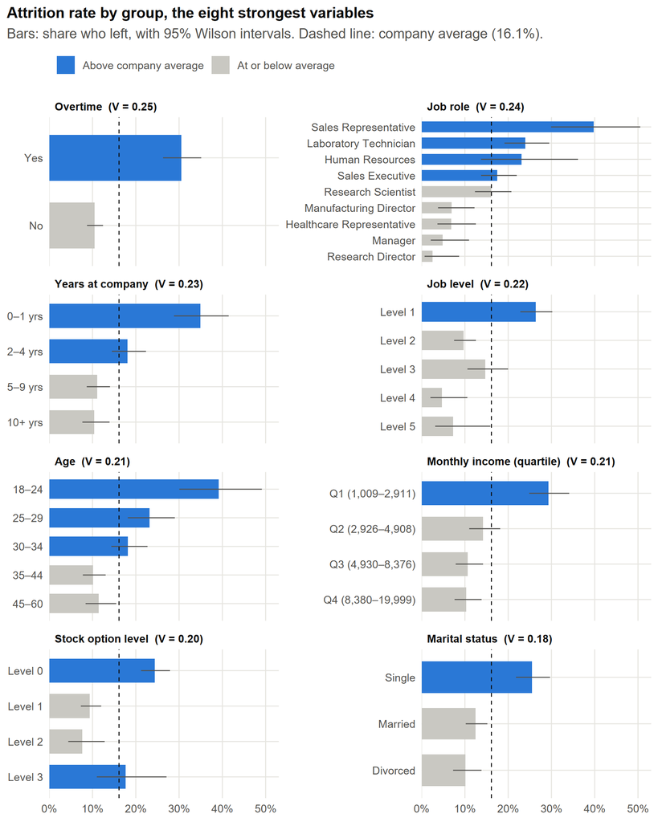

```r
seg_plot <- bind_rows(lapply(segments[1:8], function(s) {
  lv <- s$levels
  if (s$kind == "nominal") lv <- lv[order(lv$rate), ] else lv <- lv[rev(seq_len(nrow(lv))), ]
  data.frame(panel = sprintf("%s  (V = %.2f)", s$label, s$cramers_v),
             key = paste(s$key, lv$level, sep = "___"), lv)
}))
seg_plot$key   <- factor(seg_plot$key, levels = unique(seg_plot$key))
seg_plot$panel <- factor(seg_plot$panel, levels = unique(seg_plot$panel))
seg_plot$above <- ifelse(seg_plot$rate > overall_rate, "Above company average", "At or below average")

ggplot(seg_plot, aes(x = rate, y = key, fill = above)) +
  geom_col(width = 0.68) +
  geom_errorbar(aes(xmin = ci_low, xmax = ci_high), width = 0, orientation = "y", colour = ink2, linewidth = 0.4) +
  geom_vline(xintercept = overall_rate, linetype = "dashed", colour = ink, linewidth = 0.4) +
  facet_wrap(~ panel, ncol = 2, scales = "free_y") +
  scale_y_discrete(labels = function(x) sub(".*___", "", x)) +
  scale_x_continuous(labels = pct_axis, expand = expansion(mult = c(0, 0.05))) +
  scale_fill_manual(values = c("Above company average" = blue, "At or below average" = "#c9c8c2")) +
  labs(title = "Attrition rate by group, the eight strongest variables",
       subtitle = sprintf("Bars: share who left, with 95%% Wilson intervals. Dashed line: company average (%s).",
                          pct(overall_rate, 1)),
       x = NULL, y = NULL)
```

```r
seg_tests %>%
  transmute(Variable = variable, `Chi-square` = round(chi2, 1), df,
            `p-value` = ifelse(p_value < 0.001, "< 0.001", sprintf("%.3f", p_value)),
            `Cramér's V` = round(cramers_v, 2)) %>%
  knitr::kable(align = "lrrrr")
```

| Variable | Chi-square | df | p-value | Cramér’s V |
| --- | --- | --- | --- | --- |
| Overtime | 89.0 | 1 | < 0.001 | 0.25 |
| Job role | 86.2 | 8 | < 0.001 | 0.24 |
| Years at company | 75.8 | 3 | < 0.001 | 0.23 |
| Job level | 72.5 | 4 | < 0.001 | 0.22 |
| Age | 66.0 | 4 | < 0.001 | 0.21 |
| Monthly income (quartile) | 65.5 | 3 | < 0.001 | 0.21 |
| Stock option level | 60.6 | 3 | < 0.001 | 0.20 |
| Marital status | 46.2 | 2 | < 0.001 | 0.18 |
| Business travel | 24.2 | 2 | < 0.001 | 0.13 |
| Environment satisfaction | 22.5 | 3 | < 0.001 | 0.12 |
| Job satisfaction | 17.5 | 3 | < 0.001 | 0.11 |
| Work-life balance | 16.3 | 3 | < 0.001 | 0.11 |
| Distance from home | 11.4 | 3 | 0.010 | 0.09 |
| Department | 10.8 | 2 | 0.005 | 0.09 |

All 14 variables differ significantly at the 5% level, which is expected with 1,470 people. Effect size is the better guide, and the ranking is clear: **overtime**, **job role**, **tenure**, **job level**, **age** and **pay** lead. Many of these overlap: junior people are younger, newer and paid less. The regression below separates them.

## 3. What predicts leaving, all else equal?

A logistic regression estimates each factor’s effect while holding the others constant. I chose an interpretable set of 16 predictors and left out near-duplicates: monthly income tracks job level (r = 0.95), and years in role or with the current manager track years at company (r ≈ 0.77). Gender is excluded on purpose. Age and marital status stay in only as controls, so the effects of the levers HR can act on are not confounded by them.

```r
# One interpretable predictor set. Choices:
# * Binary flags read as "this group vs everyone else"; the rest are per-unit slopes.
# * JobLevel is kept (as entry level vs 2+); MonthlyIncome and TotalWorkingYears are
#   left out because they are near-duplicates of it (r = 0.95 and 0.78).
# * YearsInCurrentRole / YearsWithCurrManager duplicate YearsAtCompany (r ~ 0.77).
# * Gender is left out on purpose; age and marital status stay in as controls so the
#   other effects are not confounded, never as levers to act on individuals.
# * Nothing measured after the exit decision is used, so there is no leakage.
model_df <- hr %>% transmute(
  EmployeeNumber,
  left,
  Overtime                   = as.integer(OverTime == "Yes"),
  EntryLevel                 = as.integer(JobLevel == 1),
  NoStockOptions             = as.integer(StockOptionLevel == 0),
  Single                     = as.integer(MaritalStatus == "Single"),
  FrequentTravel             = as.integer(BusinessTravel == "Travel_Frequently"),
  LowJobSatisfaction         = as.integer(JobSatisfaction == 1),
  LowEnvironmentSatisfaction = as.integer(EnvironmentSatisfaction == 1),
  LowJobInvolvement          = as.integer(JobInvolvement == 1),
  PoorWorkLifeBalance        = as.integer(WorkLifeBalance == 1),
  DeptSales                  = as.integer(Department == "Sales"),
  DeptHR                     = as.integer(Department == "Human Resources"),
  Age10                      = Age / 10,
  YearsAtCompany,
  YearsSinceLastPromotion,
  NumCompaniesWorked,
  Distance10                 = DistanceFromHome / 10
)

term_labels <- c(
  Overtime                   = "Works overtime (vs not)",
  EntryLevel                 = "Job level 1 (vs level 2+)",
  NoStockOptions             = "No stock options (vs any)",
  Single                     = "Single (vs married or divorced)",
  FrequentTravel             = "Travels frequently (vs rarely or never)",
  LowJobSatisfaction         = "Low job satisfaction (1 of 4)",
  LowEnvironmentSatisfaction = "Low environment satisfaction (1 of 4)",
  LowJobInvolvement          = "Low job involvement (1 of 4)",
  PoorWorkLifeBalance        = "Poor work-life balance (1 of 4)",
  DeptSales                  = "Sales department (vs R&D)",
  DeptHR                     = "HR department (vs R&D)",
  Age10                      = "Age, per +10 years",
  YearsAtCompany             = "Years at company, per +1",
  YearsSinceLastPromotion    = "Years since last promotion, per +1",
  NumCompaniesWorked         = "Number of prior employers, per +1",
  Distance10                 = "Distance from home, per +10 units"
)
predictors <- names(term_labels)
f_logit <- reformulate(predictors, response = "left")
# Validate the specification on the hold-out, then refit on everyone for the
# reported odds ratios and the what-if (more data, tighter intervals).
fit_train <- glm(f_logit, family = binomial, data = train)
fit_full  <- glm(f_logit, family = binomial, data = model_df)

or_tab <- suppressMessages(tidy(fit_full, exponentiate = TRUE, conf.int = TRUE)) %>%
  filter(term != "(Intercept)") %>%
  transmute(term, label = unname(term_labels[term]), odds_ratio = estimate,
            ci_low = conf.low, ci_high = conf.high, p_value = p.value,
            significant = p.value < 0.05) %>%
  arrange(desc(odds_ratio))

null_dev <- glm(left ~ 1, family = binomial, data = model_df)
pseudo_r2 <- 1 - as.numeric(logLik(fit_full)) / as.numeric(logLik(null_dev))  # McFadden
```

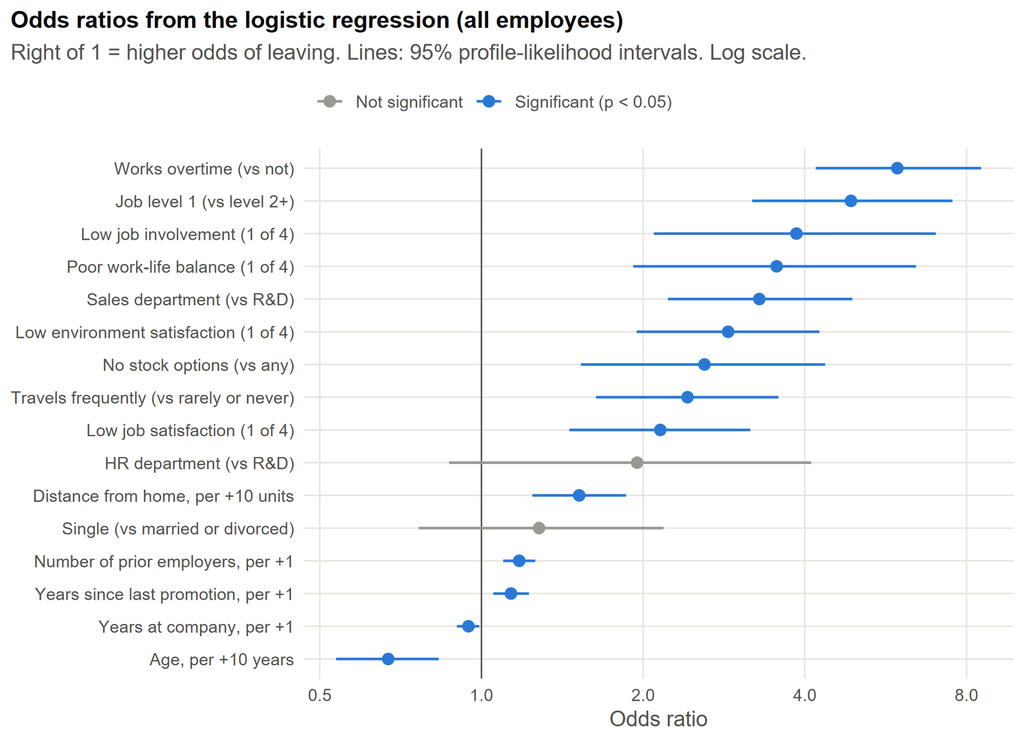

```r
or_plot <- or_tab %>%
  mutate(label = factor(label, levels = rev(label)),
         sig = ifelse(significant, "Significant (p < 0.05)", "Not significant"))
ggplot(or_plot, aes(x = odds_ratio, y = label, colour = sig)) +
  geom_vline(xintercept = 1, colour = ink2, linewidth = 0.4) +
  geom_errorbar(aes(xmin = ci_low, xmax = ci_high), width = 0, orientation = "y", linewidth = 0.7) +
  geom_point(size = 2.6) +
  scale_x_log10(breaks = c(0.5, 1, 2, 4, 8)) +
  scale_colour_manual(values = c("Significant (p < 0.05)" = blue, "Not significant" = muted)) +
  labs(title = "Odds ratios from the logistic regression (all employees)",
       subtitle = "Right of 1 = higher odds of leaving. Lines: 95% profile-likelihood intervals. Log scale.",
       x = "Odds ratio", y = NULL)
```

```r
or_tab %>%
  transmute(Factor = label, `Odds ratio` = sprintf("%.2f", odds_ratio),
            `95% CI` = sprintf("%.2f to %.2f", ci_low, ci_high),
            `p-value` = ifelse(p_value < 0.001, "< 0.001", sprintf("%.3f", p_value))) %>%
  knitr::kable(align = "lrrr")
```

| Factor | Odds ratio | 95% CI | p-value |
| --- | --- | --- | --- |
| Works overtime (vs not) | 5.95 | 4.19 to 8.52 | < 0.001 |
| Job level 1 (vs level 2+) | 4.88 | 3.19 to 7.53 | < 0.001 |
| Low job involvement (1 of 4) | 3.86 | 2.09 to 7.01 | < 0.001 |
| Poor work-life balance (1 of 4) | 3.54 | 1.92 to 6.44 | < 0.001 |
| Sales department (vs R&D) | 3.29 | 2.22 to 4.90 | < 0.001 |
| Low environment satisfaction (1 of 4) | 2.88 | 1.95 to 4.26 | < 0.001 |
| No stock options (vs any) | 2.60 | 1.53 to 4.36 | < 0.001 |
| Travels frequently (vs rarely or never) | 2.42 | 1.63 to 3.57 | < 0.001 |
| Low job satisfaction (1 of 4) | 2.15 | 1.46 to 3.17 | < 0.001 |
| HR department (vs R&D) | 1.95 | 0.87 to 4.11 | 0.090 |
| Distance from home, per +10 units | 1.52 | 1.24 to 1.86 | < 0.001 |
| Single (vs married or divorced) | 1.28 | 0.76 to 2.18 | 0.355 |
| Number of prior employers, per +1 | 1.18 | 1.10 to 1.26 | < 0.001 |
| Years since last promotion, per +1 | 1.14 | 1.05 to 1.23 | 0.001 |
| Years at company, per +1 | 0.95 | 0.90 to 0.99 | 0.023 |
| Age, per +10 years | 0.67 | 0.54 to 0.83 | < 0.001 |

How to read it: **working overtime multiplies the odds of leaving by 5.9**, for two people who are otherwise alike. Job level 1, low job involvement, poor work-life balance, working in Sales, low environment satisfaction, having no stock options, frequent travel and low job satisfaction all at least double the odds. Distance from home, the number of prior employers and years since the last promotion add smaller amounts per unit; older age and longer tenure lower the odds. Being single is no longer significant once stock options are in the model. That is expected here: single employees in this sample *all* have stock-option level 0, so the two effects share the same people and should be read together. Odds ratios also overstate *risk* ratios when the outcome is common, so “5.9 times the odds” is not “5.9 times as likely”.

## 4. How well can risk be ranked?

The same model was fitted on a 70% training split (stratified on the outcome, `set.seed(2026)`) and scored on the 441 people it had never seen.

```r
# 70/30 split, stratified on the outcome so both halves keep the 16% attrition rate.
set.seed(SEED)
idx_left <- which(model_df$left == 1)
idx_stay <- which(model_df$left == 0)
train_idx <- sort(c(sample(idx_left, round(0.7 * length(idx_left))),
                    sample(idx_stay, round(0.7 * length(idx_stay)))))
train <- model_df[train_idx, ]
test  <- model_df[-train_idx, ]
# AUC via the rank (Mann-Whitney) formula: the probability that a random leaver
# gets a higher predicted risk than a random stayer. Ties count half via mid-ranks.
auc_mw <- function(p, y) {
  r <- rank(p)
  n1 <- sum(y == 1); n0 <- sum(y == 0)
  (sum(r[y == 1]) - n1 * (n1 + 1) / 2) / (n1 * n0)
}

p_train   <- fitted(fit_train)
p_test    <- predict(fit_train, newdata = test, type = "response")
auc_train <- auc_mw(p_train, train$left)
auc_test  <- auc_mw(p_test, test$left)
brier     <- mean((p_test - test$left)^2)

# Benchmark: what does overtime alone achieve?
fit_ot_only <- glm(left ~ Overtime, family = binomial, data = train)
auc_ot_only <- auc_mw(predict(fit_ot_only, newdata = test, type = "response"), test$left)

# Calibration: within each decile of predicted risk, does the predicted rate match reality?
calib <- data.frame(p = p_test, y = test$left) %>%
  mutate(decile = ntile(p, 10)) %>%
  group_by(decile) %>%
  summarise(n = n(), leavers = sum(y), mean_predicted = mean(p), actual_rate = mean(y),
            p_min = min(p), p_max = max(p), .groups = "drop")

# Confusion matrix when HR flags the riskiest 20% of the hold-out group.
thr  <- unname(quantile(p_test, 1 - TOP_SHARE))
flag <- p_test >= thr
cm <- list(
  threshold = thr, flagged = sum(flag), test_n = nrow(test),
  tp = sum(flag & test$left == 1), fp = sum(flag & test$left == 0),
  fn = sum(!flag & test$left == 1), tn = sum(!flag & test$left == 0))
cm$precision   <- cm$tp / (cm$tp + cm$fp)
cm$recall      <- cm$tp / (cm$tp + cm$fn)
cm$specificity <- cm$tn / (cm$tn + cm$fp)
cm$accuracy    <- (cm$tp + cm$tn) / cm$test_n
cm$base_rate   <- mean(test$left)
cm$lift        <- cm$precision / cm$base_rate

# Gains: flag the top k% by risk -> what share of all leavers is caught?
ord     <- order(p_test, decreasing = TRUE)
y_ord   <- test$left[ord]
gains   <- data.frame(share_flagged = seq(0.05, 1, by = 0.05)) %>%
  mutate(k = ceiling(share_flagged * length(y_ord)),
         leavers_caught = cumsum(y_ord)[k],
         share_of_leavers = leavers_caught / sum(y_ord),
         precision = leavers_caught / k)

# ROC curve, thinned to about 60 points for the browser.
roc_points <- function(p, y, max_pts = 60) {
  cuts <- sort(unique(p), decreasing = TRUE)
  df <- data.frame(fpr = c(0, vapply(cuts, function(t) mean(p[y == 0] >= t), 0)),
                   tpr = c(0, vapply(cuts, function(t) mean(p[y == 1] >= t), 0)))
  df[unique(round(seq(1, nrow(df), length.out = max_pts))), ]
}
roc <- roc_points(p_test, test$left)
```

- **AUC 0.82** on the hold-out (training 0.86; the small gap means little overfitting). Overtime alone reaches 0.64. AUC is computed with the rank (Mann-Whitney) formula: the chance that a random leaver is scored above a random stayer.
- **Brier score 0.088** (mean squared error of the probabilities).

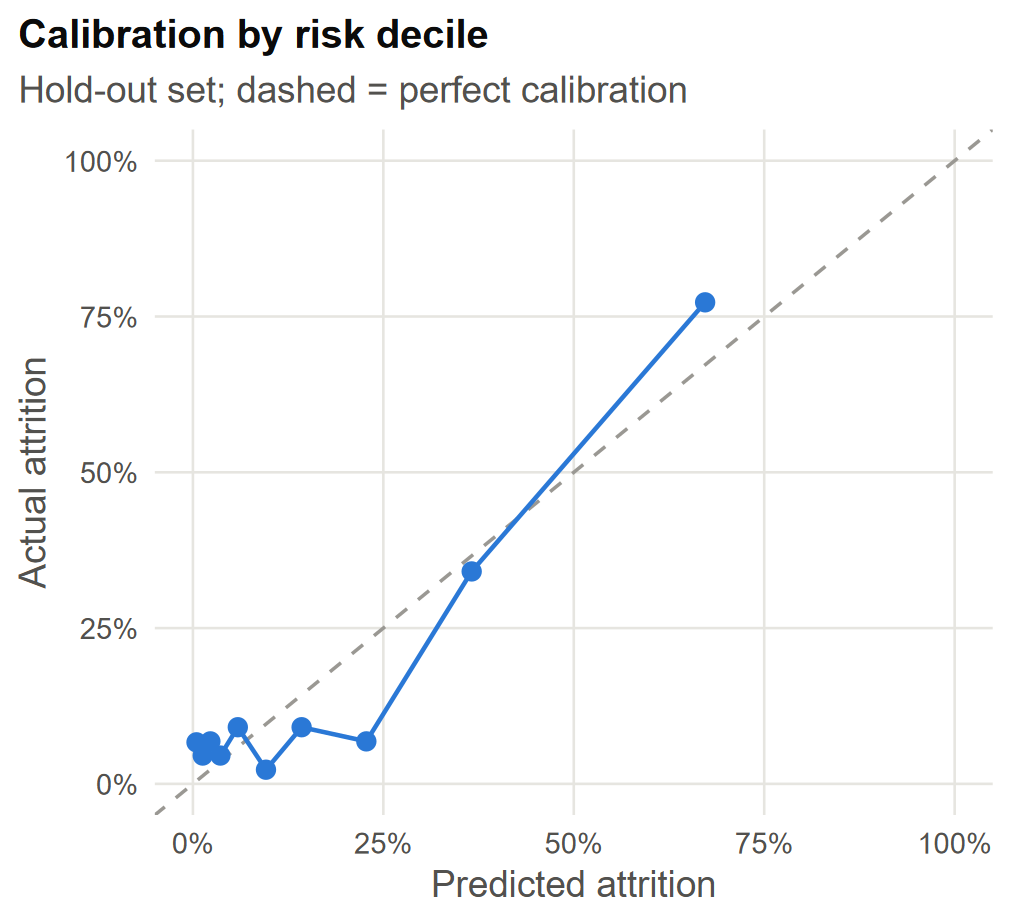

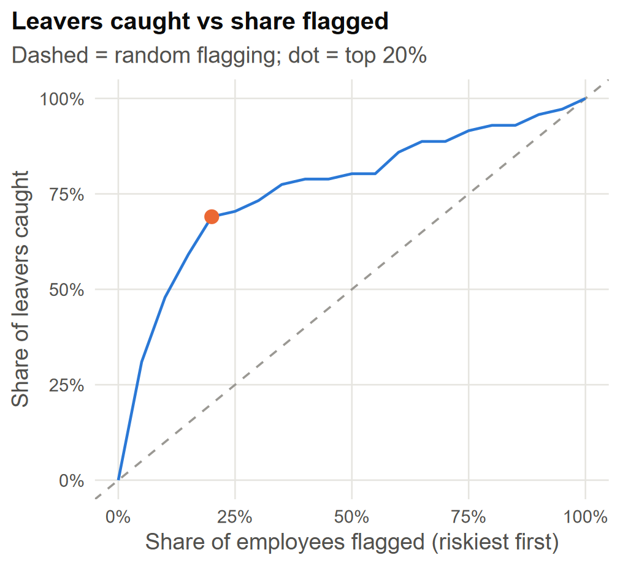

```r
ggplot(calib, aes(mean_predicted, actual_rate)) +
  geom_abline(slope = 1, intercept = 0, colour = muted, linetype = "dashed") +
  geom_line(colour = blue, linewidth = 0.7) +
  geom_point(colour = blue, size = 2.4) +
  scale_x_continuous(labels = pct_axis, limits = c(0, 1)) +
  scale_y_continuous(labels = pct_axis, limits = c(0, 1)) +
  labs(title = "Calibration by risk decile", subtitle = "Hold-out set; dashed = perfect calibration",
       x = "Predicted attrition", y = "Actual attrition")

ggplot(bind_rows(data.frame(share_flagged = 0, share_of_leavers = 0), gains),
       aes(share_flagged, share_of_leavers)) +
  geom_abline(slope = 1, intercept = 0, colour = muted, linetype = "dashed") +
  geom_line(colour = blue, linewidth = 0.7) +
  geom_point(data = filter(gains, abs(share_flagged - TOP_SHARE) < 1e-9), colour = orange, size = 3) +
  scale_x_continuous(labels = pct_axis) + scale_y_continuous(labels = pct_axis) +
  coord_cartesian(xlim = c(0, 1), ylim = c(0, 1)) +
  labs(title = "Leavers caught vs share flagged", subtitle = "Dashed = random flagging; dot = top 20%",
       x = "Share of employees flagged (riskiest first)", y = "Share of leavers caught")
```

The model ranks well but is not perfectly calibrated: the riskiest decile is under-predicted and deciles 6-8 are over-predicted, about what one expects from 71 hold-out leavers. If HR flagged the **riskiest 20%** of the hold-out group (predicted probability ≥ 0.29):

```r
data.frame(` ` = c("Flagged (top 20%)", "Not flagged"),
           `Actually left` = c(cm$tp, cm$fn), `Stayed` = c(cm$fp, cm$tn), check.names = FALSE) %>%
  knitr::kable(align = "lrr")
```

|  | Actually left | Stayed |
| --- | --- | --- |
| Flagged (top 20%) | 49 | 40 |
| Not flagged | 22 | 330 |

That list would contain **69% of the people who left**, and **55% of the people on it would actually leave**, 3.4 times the 16% base rate. Useful for prioritising conversations; far too uncertain to justify any decision about an individual.

## 5. When do people leave?

**A trap first.** The textbook Kaplan-Meier curve (time = years at company, stayers censored) assumes we saw everyone’s whole tenure. This file is a snapshot: it lists people who were employed during one period and flags who left during it. People who left in earlier years are not in it. The textbook curve still places every long-tenured stayer in the first-year risk set, though nobody could have seen them leave in their first year a decade ago. The result is a curve that hides early exits: it puts first-year retention at **98.9%**, while **36%** of the first-year employees in the file left.

**The fix is delayed entry** (left truncation). I assume `Attrition` covers one year (the usual reading of this dataset), so someone with *k* completed years was at risk only between tenure *k* and *k* + 1: `Surv(start = k, stop = k + 1, event)`. The curve then reads as a synthetic cohort: *if this year’s exit rates at each tenure held, what share of new hires would still be here after t years?* The raw exit rate in each tenure year comes first, because it needs no model at all.

```r
# WHEN do people leave? Time = years at company (recorded in whole years).
#
# Why not the textbook Kaplan-Meier? The file is a one-period snapshot: Attrition
# flags people who left during the observation window, and anyone who left in
# earlier years is simply absent. The textbook curve (time = tenure, stayers
# censored) still places every long-tenured stayer in the early-tenure risk sets,
# although nobody could have been seen leaving at that tenure years ago. That is
# left truncation, and it hides early exits: the textbook curve says 99% of hires
# survive year 1 while 36% of first-year employees in the file left.
#
# Fix: delayed entry. Assume the window is one year (the usual reading of this
# data as 16% annual attrition). An employee with k completed years was then at
# risk only from tenure k to k + 1, so each person is Surv(start = k, stop = k + 1).
# The curve is a synthetic cohort: "if this year's exit rates by tenure held, the
# share of new hires still here after t years". Group membership (overtime, job
# level) is measured today and can change over a career.
surv_df <- hr %>% transmute(
  YearsAtCompany,
  start     = YearsAtCompany,
  stop      = YearsAtCompany + 1,
  event     = left,
  OverTime  = factor(OverTime, levels = c("No", "Yes")),
  JobLevel5 = factor(paste("Level", JobLevel)),          # all five levels (textbook view)
  # levels 4 and 5 have 0-6 people per early tenure year, so 3-5 are pooled
  JobLevel  = factor(ifelse(JobLevel >= 3, paste0("Level 3", dash, "5"), paste("Level", JobLevel))))

km_all <- survfit(Surv(start, stop, event) ~ 1,        data = surv_df)
km_ot  <- survfit(Surv(start, stop, event) ~ OverTime, data = surv_df)
km_jl  <- survfit(Surv(start, stop, event) ~ JobLevel, data = surv_df)

# survdiff() has no delayed-entry form. The Cox score test with one group factor
# is the log-rank test generalised to (start, stop] data.
score_test <- function(var) {
  s <- summary(coxph(as.formula(paste("Surv(start, stop, event) ~", var)), data = surv_df))$sctest
  list(method = "log-rank (Cox score test, delayed entry)",
       chi2 = unname(s["test"]), df = unname(s["df"]), p_value = unname(s["pvalue"]))
}
logrank <- function(sd) {                        # classic survdiff, for the textbook view
  df <- length(sd$n) - 1
  list(method = "log-rank (survdiff, no delayed entry)",
       chi2 = unname(sd$chisq), df = df, p_value = pchisq(sd$chisq, df, lower.tail = FALSE))
}

# Tidy each stratum of a survfit: step points, retention checkpoints, median, and
# how many people stand behind each estimate (risk sets are small at some tenures).
km_groups <- function(fit, data, var = NULL) {
  groups <- if (is.null(var)) "All employees" else levels(data[[var]])
  grp <- if (is.null(fit$strata)) rep(groups, length(fit$time)) else rep(sub("^[^=]+=", "", names(fit$strata)), fit$strata)
  tab <- summary(fit)$table
  if (is.null(dim(tab))) tab <- t(as.matrix(tab))
  chk <- summary(fit, times = KM_YEARS, extend = TRUE)
  chk_grp <- if (is.null(chk$strata)) rep(groups, length(chk$time)) else sub("^[^=]+=", "", as.character(chk$strata))
  lapply(seq_along(groups), function(i) {
    g <- groups[i]
    d <- if (is.null(var)) data else data[data[[var]] == g, ]
    st <- if ("start" %in% names(d)) d$start else rep(0, nrow(d))
    risk_at  <- function(u) sum(st < u & d$stop >= u)          # people at risk at step u
    min_risk <- function(t) min(vapply(seq_len(t), risk_at, 0))  # weakest step up to t
    sel <- grp == g
    curve <- data.frame(time = c(0, fit$time[sel]), surv = c(1, fit$surv[sel]),
                        lower = c(1, fit$lower[sel]), upper = c(1, fit$upper[sel]),
                        n_risk = c(risk_at(1), fit$n.risk[sel]), n_event = c(0, fit$n.event[sel]))
    cs <- chk_grp == g
    retention <- data.frame(year = chk$time[cs], surv = chk$surv[cs],
                            lower = chk$lower[cs], upper = chk$upper[cs])
    retention$min_n_risk <- vapply(retention$year, min_risk, 0)
    retention$reliable   <- retention$min_n_risk >= KM_MIN_RISK
    retention$surv[retention$min_n_risk == 0] <- NA            # nobody observed: not estimable
    med <- unname(tab[i, "median"])
    supported <- which(vapply(1:20, risk_at, 0) >= KM_MIN_RISK)
    list(group = g, n = nrow(d), events = sum(d$event),
         median_years = med,
         median_ci = unname(tab[i, c("0.95LCL", "0.95UCL")]),
         median_reliable = !is.na(med) && min_risk(med) >= KM_MIN_RISK,
         display_max_time = if (length(supported)) max(supported) else 0,
         sparse_steps = if (length(supported)) setdiff(seq_len(max(supported)), supported) else integer(0),
         retention = retention, curve = curve)
  })
}

km <- list(
  overall      = km_groups(km_all, surv_df)[[1]],
  by_overtime  = list(logrank = score_test("OverTime"), groups = km_groups(km_ot, surv_df, "OverTime")),
  by_job_level = list(logrank = score_test("JobLevel"), groups = km_groups(km_jl, surv_df, "JobLevel")))

# The same question without the survival machinery: exit rate in each tenure year.
exit_rates <- function(d) {
  d %>% mutate(tenure_year = pmin(YearsAtCompany + 1, 11)) %>%
    group_by(tenure_year) %>%
    summarise(at_risk = n(), leavers = sum(left), .groups = "drop") %>%
    mutate(label = ifelse(tenure_year == 11, "11+", as.character(tenure_year)),
           rate = leavers / at_risk) %>%
    select(tenure_year, label, at_risk, leavers, rate)
}
exit_by_tenure <- list(overall = exit_rates(hr),
                       overtime_no  = exit_rates(filter(hr, OverTime == "No")),
                       overtime_yes = exit_rates(filter(hr, OverTime == "Yes")))

# Share of all leavers who left within their first two years (YearsAtCompany 0 or 1),
# and the first-two-years exit rate with and without overtime.
early_exit_share <- mean(hr$YearsAtCompany[hr$left == 1] <= 1)
early_rate <- hr %>% filter(YearsAtCompany <= 1) %>% group_by(OverTime) %>%
  summarise(n = n(), rate = mean(left), .groups = "drop")
# The textbook version, kept for comparison: time = tenure, stayers censored, no
# delayed entry (stop = YearsAtCompany + 1 so the steps line up with the curve above).
km_naive_all <- survfit(Surv(stop, event) ~ 1,         data = surv_df)
km_naive_ot  <- survfit(Surv(stop, event) ~ OverTime,  data = surv_df)
km_naive_jl  <- survfit(Surv(stop, event) ~ JobLevel5, data = surv_df)
naive_df <- select(surv_df, -start)
km_naive <- list(
  overall      = km_groups(km_naive_all, naive_df)[[1]],
  by_overtime  = list(logrank = logrank(survdiff(Surv(stop, event) ~ OverTime, data = surv_df)),
                      groups  = km_groups(km_naive_ot, naive_df, "OverTime")),
  by_job_level = list(logrank = logrank(survdiff(Surv(stop, event) ~ JobLevel5, data = surv_df)),
                      groups  = km_groups(km_naive_jl, naive_df, "JobLevel5")))
```

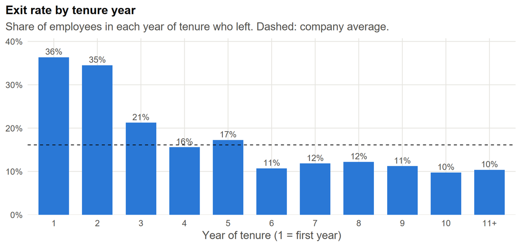

```r
ggplot(exit_by_tenure$overall, aes(x = factor(label, levels = label), y = rate)) +
  geom_col(fill = blue, width = 0.7) +
  geom_hline(yintercept = overall_rate, linetype = "dashed", colour = ink, linewidth = 0.4) +
  geom_text(aes(label = pct(rate)), vjust = -0.4, size = 3.3, colour = ink2) +
  scale_y_continuous(labels = pct_axis, expand = expansion(mult = c(0, 0.12))) +
  labs(title = "Exit rate by tenure year", subtitle = "Share of employees in each year of tenure who left. Dashed: company average.",
       x = "Year of tenure (1 = first year)", y = NULL)
```

```r
HORIZON <- 10
km_frame <- function(groups) bind_rows(lapply(groups, function(g) data.frame(group = g$group, g$curve))) %>%
  filter(time <= HORIZON)
km_plot <- function(df, colours, title, subtitle) {
  rects <- df %>% group_by(group) %>% arrange(time, .by_group = TRUE) %>%
    mutate(xmax = lead(time, default = HORIZON)) %>% filter(time < HORIZON) %>% ungroup()
  ggplot(df, aes(time, surv, colour = group)) +
    geom_rect(data = rects, aes(xmin = time, xmax = xmax, ymin = lower, ymax = upper, fill = group),
              inherit.aes = FALSE, alpha = 0.12) +
    geom_step(linewidth = 0.8) +
    scale_colour_manual(values = colours) + scale_fill_manual(values = colours, guide = "none") +
    scale_x_continuous(breaks = 0:HORIZON) +
    scale_y_continuous(labels = pct_axis, limits = c(0, 1)) +
    labs(title = title, subtitle = subtitle, x = "Years since joining", y = "Still employed")
}
```

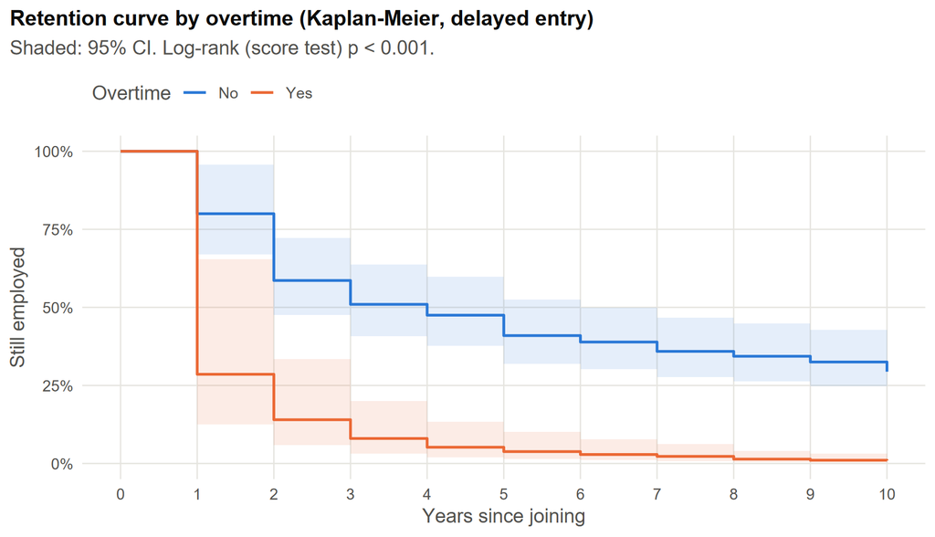

```r
km_plot(km_frame(km$by_overtime$groups), c(No = blue, Yes = orange),
        "Retention curve by overtime (Kaplan-Meier, delayed entry)",
        sprintf("Shaded: 95%% CI. Log-rank (score test) p %s.", fmt_p(km$by_overtime$logrank$p_value))) +
  labs(colour = "Overtime") + theme(legend.title = element_text(colour = ink2))
```

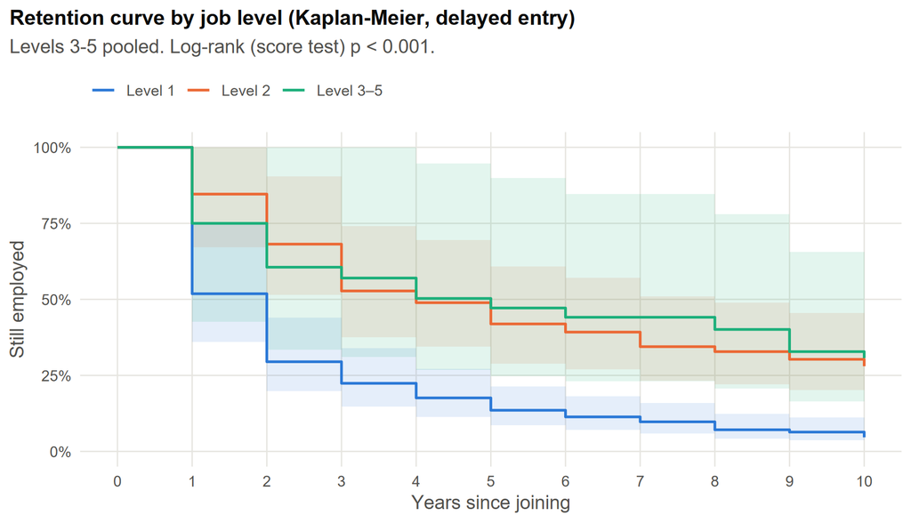

```r
jl_cols <- setNames(c(blue, orange, aqua), levels(surv_df$JobLevel))
km_plot(km_frame(km$by_job_level$groups), jl_cols,
        "Retention curve by job level (Kaplan-Meier, delayed entry)",
        sprintf("Levels 3-5 pooled. Log-rank (score test) p %s.", fmt_p(km$by_job_level$logrank$p_value)))
```

```r
ret_rows <- function(g) data.frame(Group = g$group, People = g$n, Leavers = g$events,
  t(setNames(ifelse(g$retention$reliable, pct(g$retention$surv), paste0(pct(g$retention$surv), "*")),
             paste("After", g$retention$year, ifelse(g$retention$year == 1, "year", "years")))),
  check.names = FALSE)
bind_rows(ret_rows(km$overall), lapply(km$by_overtime$groups, ret_rows), lapply(km$by_job_level$groups, ret_rows)) %>%
  mutate(Group = c("All employees", paste("Overtime:", c("No", "Yes")), levels(surv_df$JobLevel))) %>%
  knitr::kable(align = "lrrrrrr")
```

| Group | People | Leavers | After 1 year | After 2 years | After 5 years | After 10 years |
| --- | --- | --- | --- | --- | --- | --- |
| All employees | 1470 | 237 | 64% | 42% | 23% | 13% |
| Overtime: No | 1054 | 110 | 80% | 59% | 41% | 29% |
| Overtime: Yes | 416 | 127 | 29% | 14% | 4% | 1% |
| Level 1 | 543 | 143 | 52% | 29% | 14% | 5% |
| Level 2 | 534 | 52 | 85% | 68% | 42% | 28% |
| Level 3–5 | 393 | 42 | 75%* | 61%* | 47%* | 31%* |

`*` fewer than 10 people stood behind at least one step of that estimate (only 4 people at levels 3-5 were in their first year), so it is not reliable.

The picture is consistent: **exits concentrate in the first two years** (35% of employees in their first two years left, against 11% at 5-9 years), and **overtime workers leave sooner at every stage**. Median time to exit for a synthetic new-hire cohort is 1 year for overtime workers and 4 years for everyone else. Compounding is what makes these numbers look harsh: a 30% annual exit rate leaves fewer than 3% of a cohort after ten years. They describe today’s exit rates projected forward, not a real cohort.

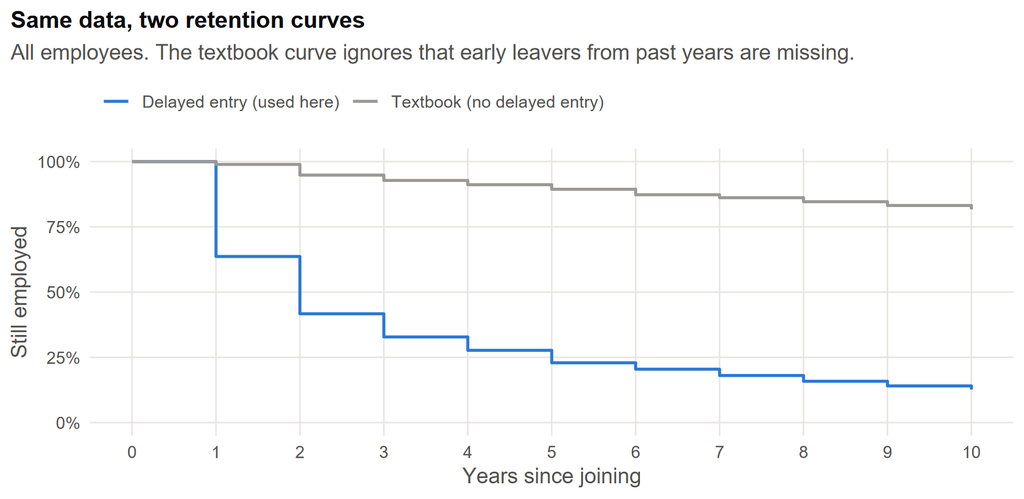

```r
cmp <- bind_rows(
  data.frame(version = "Textbook (no delayed entry)", km_naive$overall$curve),
  data.frame(version = "Delayed entry (used here)", km$overall$curve)) %>%
  filter(time <= HORIZON)
ggplot(cmp, aes(time, surv, colour = version)) +
  geom_step(linewidth = 0.8) +
  scale_colour_manual(values = c("Textbook (no delayed entry)" = muted, "Delayed entry (used here)" = blue)) +
  scale_x_continuous(breaks = 0:HORIZON) + scale_y_continuous(labels = pct_axis, limits = c(0, 1)) +
  labs(title = "Same data, two retention curves", subtitle = "All employees. The textbook curve ignores that early leavers from past years are missing.",
       x = "Years since joining", y = "Still employed")
```

**Cox model.** A Cox proportional-hazards model with the same delayed entry asks which traits make people leave *sooner at the same tenure*. The textbook version is shown for contrast: without delayed entry, traits tied to short tenure (job level 1) look about twice as strong as they are.

```r
# Cox proportional hazards with delayed entry, on levers HR can act on plus marital
# status as a control. Hazard ratio > 1 = leaves sooner at the same tenure.
cox_terms <- c("Overtime", "EntryLevel", "NoStockOptions", "Single", "FrequentTravel",
               "LowJobSatisfaction", "LowEnvironmentSatisfaction")
cox_df  <- model_df %>% mutate(start = hr$YearsAtCompany, stop = start + 1, event = left)
cox_rhs <- paste(cox_terms, collapse = " + ")
cox_fit <- coxph(as.formula(paste("Surv(start, stop, event) ~", cox_rhs)), data = cox_df)
cox_zph <- cox.zph(cox_fit)                       # proportional-hazards check
cox_tab <- tidy(cox_fit, exponentiate = TRUE, conf.int = TRUE) %>%
  transmute(term, label = unname(term_labels[term]), hazard_ratio = estimate,
            ci_low = conf.low, ci_high = conf.high, p_value = p.value,
            significant = p.value < 0.05) %>%
  arrange(desc(hazard_ratio))

# Same model without delayed entry: tenure-linked traits (job level) look far
# stronger than they are, which is the left-truncation bias in action.
cox_naive <- coxph(as.formula(paste("Surv(stop, event) ~", cox_rhs)), data = cox_df)
cox_naive_tab <- tidy(cox_naive, exponentiate = TRUE, conf.int = TRUE) %>%
  transmute(term, hazard_ratio_naive = estimate)
```

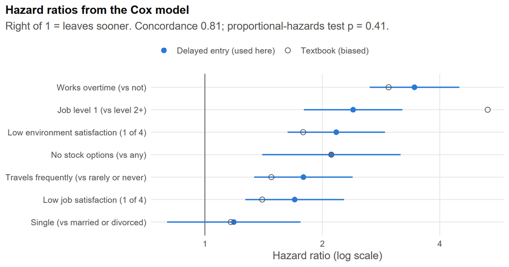

```r
cox_plot <- cox_tab %>% left_join(cox_naive_tab, by = "term") %>%
  mutate(label = factor(label, levels = rev(label)))
ggplot(cox_plot, aes(y = label)) +
  geom_vline(xintercept = 1, colour = ink2, linewidth = 0.4) +
  geom_errorbar(aes(xmin = ci_low, xmax = ci_high), width = 0, orientation = "y", colour = blue, linewidth = 0.7) +
  geom_point(aes(x = hazard_ratio, shape = "Delayed entry (used here)"), colour = blue, size = 2.6) +
  geom_point(aes(x = hazard_ratio_naive, shape = "Textbook (biased)"), colour = ink2, size = 2.4) +
  scale_shape_manual(values = c("Delayed entry (used here)" = 16, "Textbook (biased)" = 1)) +
  scale_x_log10(breaks = c(0.5, 1, 2, 4, 8)) +
  labs(title = "Hazard ratios from the Cox model",
       subtitle = sprintf("Right of 1 = leaves sooner. Concordance %.2f; proportional-hazards test p = %.2f.",
                          cox_fit$concordance["concordance"], cox_zph$table["GLOBAL", "p"]),
       x = "Hazard ratio (log scale)", y = NULL)
```

The proportional-hazards assumption holds (global test p = 0.41). Overtime has the largest effect (**HR 3.4**), followed by job level 1, low environment satisfaction and having no stock options.

## 6. Which segments are most at risk?

A decision tree finds combinations of traits with very different attrition rates. I grew a regression tree on the 0/1 outcome (`rpart`, `method = "anova"`), so each leaf’s mean *is* its attrition rate, with at least 30 people per leaf, depth ≤ 4 and cp = 0.01 (ten-fold cross-validated error falls at every retained split). A classification tree is the usual choice, but on a 16% outcome it refuses to split the large low-risk branch, because no split there changes the majority vote.

```r
# A regression tree on the 0/1 outcome (method = "anova"): each leaf's mean IS its
# attrition rate, and splits maximise the difference in rates. (A "class" tree on a
# 16% outcome refuses to split the big low-risk branch because no split changes
# the majority vote, which hides useful segments.)
tree_df <- hr %>% transmute(
  left, OverTime, JobLevel, StockOptionLevel, MaritalStatus, Age, MonthlyIncome,
  YearsAtCompany, TotalWorkingYears, JobRole, BusinessTravel, Department,
  JobSatisfaction, EnvironmentSatisfaction, WorkLifeBalance, JobInvolvement,
  DistanceFromHome, NumCompaniesWorked, YearsWithCurrManager) %>%
  mutate(across(where(is.character), factor))

set.seed(SEED)
tree_ctrl <- rpart.control(cp = 0.01, minbucket = 30, maxdepth = 4, xval = 10)
tree <- rpart(left ~ ., data = tree_df, method = "anova", control = tree_ctrl)

pretty_var <- c(
  OverTime = "Overtime", JobLevel = "Job level", StockOptionLevel = "Stock option level",
  MaritalStatus = "Marital status", Age = "Age", MonthlyIncome = "Monthly income",
  YearsAtCompany = "Years at company", TotalWorkingYears = "Total working years",
  JobRole = "Job role", BusinessTravel = "Business travel", Department = "Department",
  JobSatisfaction = "Job satisfaction", EnvironmentSatisfaction = "Environment satisfaction",
  WorkLifeBalance = "Work-life balance", JobInvolvement = "Job involvement",
  DistanceFromHome = "Distance from home", NumCompaniesWorked = "Prior employers",
  YearsWithCurrManager = "Years with current manager")
rating_vars <- c("JobSatisfaction", "EnvironmentSatisfaction", "JobInvolvement")

# Turn rpart's path ("JobLevel< 1.5", "OverTime=Yes", ...) into readable conditions:
# merge repeated splits on one variable and snap integer thresholds to whole values.
readable_conditions <- function(path) {
  parts <- regmatches(path, regexec("^([A-Za-z]+)\\s*(>=|<=|<|>|=)\\s*(.*)$", path))
  acc <- list()
  for (p in parts) {
    v <- p[2]; op <- p[3]; val <- p[4]
    if (is.null(acc[[v]])) acc[[v]] <- list(lo = NULL, hi = NULL, set = NULL)
    if (op == "=") {
      lv <- strsplit(val, ",")[[1]]
      acc[[v]]$set <- if (is.null(acc[[v]]$set)) lv else intersect(acc[[v]]$set, lv)
    } else if (op %in% c(">=", ">")) {
      acc[[v]]$lo <- max(acc[[v]]$lo, as.numeric(val))
    } else {
      acc[[v]]$hi <- min(acc[[v]]$hi, as.numeric(val))
    }
  }
  vapply(names(acc), function(v) {
    a <- acc[[v]]; nm <- pretty_var[[v]]
    if (!is.null(a$set)) {
      lv <- gsub("_", " ", a$set)
      return(if (length(lv) == 1) paste(nm, "=", lv) else paste0(nm, ": ", paste(lv, collapse = " or ")))
    }
    x <- tree_df[[v]]
    lo <- if (is.null(a$lo)) NULL else ceiling(a$lo)          # x >= 1.5  ->  x >= 2
    hi <- if (is.null(a$hi)) NULL else ceiling(a$hi) - 1      # x <  1.5  ->  x <= 1
    if (!is.null(lo) && lo <= min(x)) lo <- NULL
    if (!is.null(hi) && hi >= max(x)) hi <- NULL
    lab <- function(k) {
      if (v %in% rating_vars) return(paste0(k, " (", rating_lab[k], ")"))
      if (v == "WorkLifeBalance") return(paste0(k, " (", wlb_lab[k], ")"))
      num(k)
    }
    if (!is.null(lo) && !is.null(hi)) {
      if (lo == hi) paste(nm, "=", lab(lo)) else paste0(nm, " ", num(lo), dash, num(hi))
    } else if (!is.null(lo)) {
      if (lo == max(x)) paste(nm, "=", lab(lo)) else paste(nm, "\u2265", num(lo))
    } else if (!is.null(hi)) {
      if (hi == min(x)) {
        paste(nm, "=", lab(hi))
      } else if (length(unique(x)) > 50) {
        paste(nm, "<", num(ceiling(a$hi)))                  # wide numeric: keep the cut point
      } else {
        paste(nm, "\u2264", num(hi))
      }
    } else {
      paste(nm, "(any)")
    }
  }, "")
}

fr <- tree$frame
leaf_nodes <- as.integer(rownames(fr)[fr$var == "<leaf>"])
paths <- path.rpart(tree, nodes = leaf_nodes, print.it = FALSE)
tree_leaves <- bind_rows(lapply(seq_along(leaf_nodes), function(i) {
  row <- fr[rownames(fr) == as.character(leaf_nodes[i]), ]
  conds <- readable_conditions(paths[[i]][-1])                # drop "root"
  data.frame(node = leaf_nodes[i], rule = paste(conds, collapse = " & "),
             n = row$n, leavers = round(row$n * row$yval), rate = row$yval,
             stringsAsFactors = FALSE) %>%
    mutate(conditions = list(I(unname(conds))))              # I(): stays a JSON array even with one condition
})) %>%
  mutate(share_of_employees = n / n_emp, share_of_leavers = leavers / n_left,
         lift = rate / overall_rate,
         rule_text = sprintf("%s \u2192 %s leave (n = %s)", rule, pct(rate), num(n))) %>%
  arrange(desc(rate))

tree_importance <- data.frame(variable = names(tree$variable.importance),
                              importance = unname(tree$variable.importance)) %>%
  mutate(label = unname(pretty_var[variable]), importance = 100 * importance / sum(importance))
tree_cp <- as.data.frame(tree$cptable)
```

```r
tree_leaves %>%
  transmute(Segment = rule, People = n, Leavers = leavers, `Attrition rate` = pct(rate),
            `vs average` = sprintf("%.1f×", lift), `Share of all leavers` = pct(share_of_leavers)) %>%
  knitr::kable(align = "lrrrrr")
```

| Segment | People | Leavers | Attrition rate | vs average | Share of all leavers |
| --- | --- | --- | --- | --- | --- |
| Overtime = Yes & Monthly income < 2,475 | 69 | 48 | 70% | 4.3× | 20% |
| Overtime = Yes & Monthly income ≥ 2,475 & Job role: Laboratory Technician or Sales Executive or Sales Representative & Stock option level = 0 | 62 | 37 | 60% | 3.7× | 16% |
| Overtime = No & Total working years ≤ 2 | 88 | 29 | 33% | 2.0× | 12% |
| Overtime = Yes & Monthly income ≥ 2,475 & Job role: Laboratory Technician or Sales Executive or Sales Representative & Stock option level ≥ 1 | 85 | 17 | 20% | 1.2× | 7% |
| Overtime = Yes & Monthly income ≥ 2,475 & Job role: Healthcare Representative or Human Resources or Manager or Manufacturing Director or Research Director or Research Scientist | 200 | 25 | 12% | 0.8× | 11% |
| Overtime = No & Total working years ≥ 3 | 966 | 81 | 8% | 0.5× | 34% |

Two pockets stand out: **overtime workers on the lowest pay** (70% leave) and **overtime workers in lab, sales-executive and sales-rep roles with no stock options** (60%). Together they are 9% of employees but 36% of leavers. Without overtime, early-career people (≤ 2 years of total experience) are the one high-risk group.

## 7. What if overtime were reduced?

Using the full-data logistic model, I take each of the 416 overtime workers and compare their predicted probability of leaving with the same person’s prediction with `Overtime` set to “No”. Summing those differences gives the expected number of exits associated with overtime. “Random” moves a share of overtime workers off overtime at random; “targeted” starts with the people whose predicted risk falls the most.

```r
# Using the full-data logistic model: each overtime worker's predicted probability
# of leaving now, and the same person's probability with Overtime switched to 0.
# Associational, not causal: "if they had the attrition odds of comparable
# colleagues who do not work overtime".
p_all   <- fitted(fit_full)
is_ot   <- model_df$Overtime == 1
cf      <- model_df[is_ot, ]
cf$Overtime <- 0
p_no_ot <- unname(predict(fit_full, newdata = cf, type = "response"))
delta   <- p_all[is_ot] - p_no_ot

base_expected <- sum(p_all)     # equals the observed leavers: a property of logistic MLE
n_ot <- sum(is_ot)
delta_sorted <- sort(delta, decreasing = TRUE)
scenarios <- data.frame(share = OT_SHARES) %>%
  mutate(workers_moved = round(share * n_ot),
         # random: a share s of overtime workers, chosen at random -> linear in s
         expected_leavers_random   = base_expected - share * sum(delta),
         # targeted: the workers with the largest predicted drop go first
         expected_leavers_targeted = base_expected - vapply(workers_moved, function(k) sum(delta_sorted[seq_len(k)]), 0),
         reduction_random   = base_expected - expected_leavers_random,
         reduction_targeted = base_expected - expected_leavers_targeted,
         attrition_rate_random   = expected_leavers_random / n_emp,
         attrition_rate_targeted = expected_leavers_targeted / n_emp)

# Naive comparison for context: overtime workers at the raw non-overtime rate.
rate_ot    <- mean(hr$left[hr$OverTime == "Yes"])
rate_no_ot <- mean(hr$left[hr$OverTime == "No"])
naive_reduction <- n_ot * (rate_ot - rate_no_ot)

ot_emp <- hr[is_ot, ] %>%
  transmute(emp_no = EmployeeNumber, p_now = unname(p_all[is_ot]), p_no_ot = p_no_ot,
            monthly_income = MonthlyIncome, job_level = JobLevel, department = Department,
            left = left) %>%
  arrange(desc(p_now - p_no_ot))

# Inputs for a user-chosen replacement-cost assumption (no cost figure is asserted here).
cost_inputs <- list(
  avg_monthly_income_leavers    = mean(hr$MonthlyIncome[hr$left == 1]),
  median_monthly_income_leavers = median(hr$MonthlyIncome[hr$left == 1]),
  avg_monthly_income_all        = mean(hr$MonthlyIncome),
  avg_monthly_income_ot_leavers = mean(hr$MonthlyIncome[hr$left == 1 & hr$OverTime == "Yes"]),
  # income of the leavers the full what-if would avoid, weighted by each person's drop in risk
  avg_monthly_income_avoided    = sum(delta * hr$MonthlyIncome[is_ot]) / sum(delta))
```

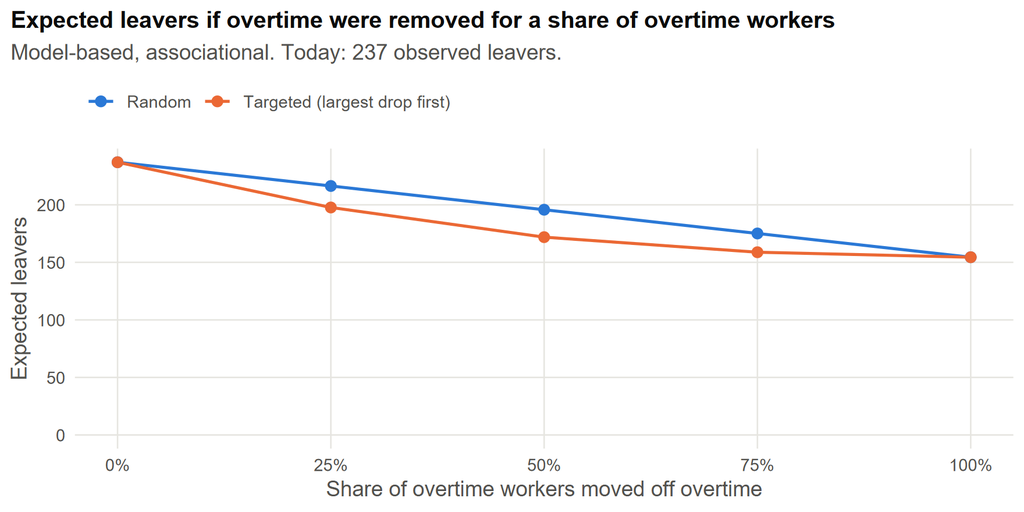

```r
wi <- bind_rows(
  data.frame(scenario = "Random", share = scenarios$share, leavers = scenarios$expected_leavers_random),
  data.frame(scenario = "Targeted (largest drop first)", share = scenarios$share, leavers = scenarios$expected_leavers_targeted))
ggplot(wi, aes(share, leavers, colour = scenario)) +
  geom_line(linewidth = 0.8) + geom_point(size = 2.4) +
  scale_colour_manual(values = c("Random" = blue, "Targeted (largest drop first)" = orange)) +
  scale_x_continuous(labels = pct_axis, breaks = OT_SHARES) +
  scale_y_continuous(limits = c(0, NA)) +
  labs(title = "Expected leavers if overtime were removed for a share of overtime workers",
       subtitle = sprintf("Model-based, associational. Today: %s observed leavers.", num(n_left)),
       x = "Share of overtime workers moved off overtime", y = "Expected leavers")
```

```r
scenarios %>%
  transmute(`Share moved off overtime` = pct(share), `Workers` = workers_moved,
            `Expected leavers (random)` = sprintf("%.0f", expected_leavers_random),
            `Expected leavers (targeted)` = sprintf("%.0f", expected_leavers_targeted),
            `Attrition rate (targeted)` = pct(attrition_rate_targeted, 1)) %>%
  knitr::kable(align = "rrrrr")
```

| Share moved off overtime | Workers | Expected leavers (random) | Expected leavers (targeted) | Attrition rate (targeted) |
| --- | --- | --- | --- | --- |
| 0% | 0 | 237 | 237 | 16.1% |
| 25% | 104 | 216 | 198 | 13.4% |
| 50% | 208 | 196 | 172 | 11.7% |
| 75% | 312 | 175 | 159 | 10.8% |
| 100% | 416 | 154 | 154 | 10.5% |

Removing overtime altogether is associated with about **83 fewer leavers** (237 → 154). Targeting gets most of that from half the workers: **65 fewer** when the 208 people whose predicted risk falls most come off overtime first. The raw rate gap gives 84; the adjusted model lands close to it, so the overtime effect is not explained away by who works overtime.

**On cost, I make no claim.** Replacement-cost estimates vary widely by role and company. The leavers in this file earn on average 4,787 a month (median 3,202, in the dataset’s own units), and the exits avoided in the full scenario belong to people earning about 5,295 a month. If replacing someone costs *m* times their annual pay, the full scenario is worth about 83 × 12 × 5,295 × *m*. The interactive version on the site lets the reader set *m*, and set it against the cost of the extra hiring that cutting overtime would need.

## 8. Recommendations: hypotheses for HR to test

None of these is proven by this analysis. Each is a hypothesis the data makes worth testing, with a way to test it.

**1. Pilot an overtime cap where overtime is chronic**

- *Hypothesis:* Cutting sustained overtime lowers voluntary attrition among the people who work it.
- *Action:* Cap or rotate overtime in a few comparable teams for two quarters; leave matched teams as they are.
- *Measure:* 12-month voluntary attrition and engagement of overtime workers, pilot vs matched teams.
- *Evidence here:* Overtime odds ratio 5.9; model-based ceiling of about 83 fewer leavers out of 237 in this sample.

**2. Strengthen the first two years**

- *Hypothesis:* Structured onboarding and early check-ins reduce first- and second-year exits.
- *Action:* Add 90-day and 12-month stay conversations, a buddy, and a clear first-promotion path for new hires.
- *Measure:* Kaplan-Meier retention at 12 and 24 months for new-hire cohorts before vs after the change.
- *Evidence here:* 35% of first- and second-year employees left (company average 16%); at these rates only 42% of new hires complete year 2.

**3. Test a retention stake for junior staff**

- *Hypothesis:* Stock options or a deferred retention bonus at job level 1 increase tenure.
- *Action:* Extend a small equity or deferred-bonus grant to level-1 staff without options, phased in by site so the late sites act as a comparison.
- *Measure:* Attrition of eligible vs not-yet-eligible level-1 staff at 12 and 24 months, against the grant cost.
- *Evidence here:* Job level 1: 26% attrition; no stock options: 24%. (In this sample every single employee has no options, so the two signals overlap.)

**4. Use risk scores to start conversations, not to decide**

- *Hypothesis:* Stay interviews with the highest-risk group prevent some exits.
- *Action:* Give managers the top-20% list for stay interviews, plus a random comparison group; never use the score for pay, promotion or exit decisions, and keep protected traits out of targeting.
- *Measure:* Exits among interviewed vs comparison employees; how many flagged people actually leave.
- *Evidence here:* Top 20% by risk holds 69% of leavers at 55% precision (base rate 16%).

## 9. Caveats

- The data is a fictional sample created by IBM data scientists, not records of a real company. Patterns are illustrative.
- It is one cross-sectional snapshot, so every result is an association. Nothing here proves that changing a factor changes attrition; the recommendations are hypotheses to test.
- IBM does not document the attrition window. The survival curves assume one year and use delayed entry, so they describe a synthetic cohort at this year’s exit rates. Tenure is in whole years, and overtime and job level are measured today, not over each career.
- The hold-out set has 441 people and 71 leavers, so AUC, precision and recall carry real sampling noise.
- In this sample every single employee has stock-option level 0, so the marital-status and stock-option effects are entangled; read them together.
- Age and marital status are included only as statistical controls. Decisions about individuals should not use protected characteristics.

## Reproduce

The analysis lives in one script; this report reads its chunks, so the numbers here and on the site come from the same code.

```
Rscript analysis/people_attrition.R <ibm_attrition.csv> data
Rscript -e "rmarkdown::render('analysis/people_attrition.Rmd', params = list(csv = '<ibm_attrition.csv>'), output_dir = 'reports')"
```

The key findings and recommendations above are assembled from the computed numbers, not typed in by hand:

```r
lvl <- function(key, level) {
  l <- segments[[key]]$levels
  l[l$level == level, ]
}
or_of  <- function(term) or_tab[or_tab$term == term, ]
ci_txt <- function(lo, hi) sprintf("95%% CI %.1f%s%.1f", lo, dash, hi)

ot_or   <- or_of("Overtime")
lvl1    <- lvl("JobLevel", "Level 1")
lvl2p   <- hr %>% filter(JobLevel >= 2) %>% summarise(r = mean(left)) %>% pull(r)
stock0  <- lvl("StockOptionLevel", "Level 0")
stock1p <- hr %>% filter(StockOptionLevel >= 1) %>% summarise(r = mean(left)) %>% pull(r)
single  <- lvl("MaritalStatus", "Single")
travel  <- lvl("BusinessTravel", "Travels frequently")
young   <- lvl("AgeBand", paste0("18", dash, "24"))
ret_at  <- function(g, y) g$retention$surv[g$retention$year == y]
ret1    <- ret_at(km$overall, 1)
ret2    <- ret_at(km$overall, 2)
ret10   <- ret_at(km$overall, 10)
t01     <- lvl("TenureBand", paste0("0", dash, "1 yrs"))
t59     <- lvl("TenureBand", paste0("5", dash, "9 yrs"))
t10p    <- lvl("TenureBand", "10+ yrs")
ot_hr   <- cox_tab[cox_tab$term == "Overtime", ]
early_ot <- early_rate$rate[early_rate$OverTime == "Yes"]
early_no <- early_rate$rate[early_rate$OverTime == "No"]
top_leaf <- tree_leaves %>% filter(n >= 30) %>% slice(1)
low_leaf <- tree_leaves %>% arrange(rate) %>% slice(1)
all_ot  <- scenarios[scenarios$share == 1, ]
half_ot <- scenarios[scenarios$share == 0.5, ]
adj_phrase <- if (all_ot$reduction_random < 0.9 * naive_reduction) {
  "adjusting for who works overtime shrinks the estimate"
} else if (all_ot$reduction_random > 1.1 * naive_reduction) {
  "adjusting for who works overtime makes the effect larger, not smaller"
} else {
  "close to the model, so the overtime effect is not explained away by who works overtime"
}

insights <- list(
  list(id = "overall", source = "baseline",
       title = "About 1 in 6 employees left",
       text = sprintf("%s of employees (%s of %s) left the company.", pct(overall_rate, 1), num(n_left), num(n_emp)),
       value = overall_rate, value_label = "attrition rate"),
  list(id = "overtime", source = "baseline + logistic",
       title = "Overtime is the sharpest single divider",
       text = sprintf("%s of overtime workers left vs %s of everyone else (%.1f\u00d7). Holding the other factors constant, overtime multiplies the odds of leaving by %.1f (%s).",
                      pct(rate_ot), pct(rate_no_ot), rate_ot / rate_no_ot, ot_or$odds_ratio, ci_txt(ot_or$ci_low, ot_or$ci_high)),
       value = ot_or$odds_ratio, value_label = "odds ratio, overtime"),
  list(id = "early_tenure", source = "baseline + survival",
       title = "Exits cluster in the first two years",
       text = sprintf("%s of employees in their first two years left, vs %s at 5%s9 years and %s at 10+. At these rates a new hire has a %s chance of completing year 1 and %s of completing year 2 (Kaplan-Meier, delayed entry).",
                      pct(t01$rate), pct(t59$rate), dash, pct(t10p$rate), pct(ret1), pct(ret2)),
       value = t01$rate, value_label = "exit rate, first two years"),
  list(id = "overtime_survival", source = "survival (Cox)",
       title = "Overtime workers leave sooner at every tenure",
       text = sprintf("At the same tenure, overtime workers leave at %.1f%s the rate of others (Cox hazard ratio, %s; log-rank p %s). In their first two years, %s of overtime workers left vs %s of the rest.",
                      ot_hr$hazard_ratio, "\u00d7", ci_txt(ot_hr$ci_low, ot_hr$ci_high),
                      fmt_p(km$by_overtime$logrank$p_value), pct(early_ot), pct(early_no)),
       value = ot_hr$hazard_ratio, value_label = "hazard ratio, overtime"),
  list(id = "junior_equity", source = "baseline",
       title = "Junior staff without equity are the most exposed",
       text = sprintf("Job level 1: %s leave vs %s at level 2+. No stock options: %s vs %s with any.",
                      pct(lvl1$rate), pct(lvl2p), pct(stock0$rate), pct(stock1p)),
       value = lvl1$rate, value_label = "attrition rate, job level 1"),
  list(id = "top_segment", source = "decision tree",
       title = "The riskiest segment the tree finds",
       text = sprintf("%s: %s leave (%s people, %s the company average). Lowest-risk segment: %s at %s.",
                      top_leaf$rule, pct(top_leaf$rate), num(top_leaf$n),
                      sprintf("%.1f\u00d7", top_leaf$lift), low_leaf$rule, pct(low_leaf$rate)),
       value = top_leaf$rate, value_label = "attrition rate, top tree segment"),
  list(id = "profile", source = "baseline",
       title = "Other strong signals",
       text = sprintf("Single employees: %s. Frequent travellers: %s. Ages 18%s24: %s. Company average: %s.",
                      pct(single$rate), pct(travel$rate), dash, pct(young$rate), pct(overall_rate)),
       value = single$rate, value_label = "attrition rate, single employees"),
  list(id = "model", source = "logistic validation",
       title = "Risk can be ranked, imperfectly",
       text = sprintf("On %s held-out employees the model scores AUC %.2f (overtime alone: %.2f). Flagging the riskiest 20%% catches %s of leavers, and %s of those flagged actually left (vs %s base rate).",
                      num(nrow(test)), auc_test, auc_ot_only, pct(cm$recall), pct(cm$precision), pct(cm$base_rate)),
       value = auc_test, value_label = "test AUC"),
  list(id = "whatif", source = "what-if (logistic)",
       title = "What overtime might be worth",
       text = sprintf("If no one worked overtime, the model expects %s leavers instead of %s (%s fewer, about %s of overtime workers' exits). Taking half of overtime workers off overtime, highest-impact first: %s fewer. The raw rate gap gives %s fewer, %s.",
                      num(all_ot$expected_leavers_random), num(base_expected), num(all_ot$reduction_random),
                      pct(all_ot$reduction_random / sum(hr$left[is_ot])), num(half_ot$reduction_targeted),
                      num(naive_reduction), adj_phrase),
       value = all_ot$reduction_random, value_label = "expected leavers avoided, all overtime removed")
)

recommendations <- list(
  list(id = "overtime_policy",
       title = "Pilot an overtime cap where overtime is chronic",
       hypothesis = "Cutting sustained overtime lowers voluntary attrition among the people who work it.",
       action = "Cap or rotate overtime in a few comparable teams for two quarters; leave matched teams as they are.",
       measure = "12-month voluntary attrition and engagement of overtime workers, pilot vs matched teams.",
       evidence = sprintf("Overtime odds ratio %.1f; model-based ceiling of about %s fewer leavers out of %s in this sample.",
                          ot_or$odds_ratio, num(all_ot$reduction_random), num(n_left))),
  list(id = "early_tenure",
       title = "Strengthen the first two years",
       hypothesis = "Structured onboarding and early check-ins reduce first- and second-year exits.",
       action = "Add 90-day and 12-month stay conversations, a buddy, and a clear first-promotion path for new hires.",
       measure = "Kaplan-Meier retention at 12 and 24 months for new-hire cohorts before vs after the change.",
       evidence = sprintf("%s of first- and second-year employees left (company average %s); at these rates only %s of new hires complete year 2.",
                          pct(t01$rate), pct(overall_rate), pct(ret2))),
  list(id = "junior_equity",
       title = "Test a retention stake for junior staff",
       hypothesis = "Stock options or a deferred retention bonus at job level 1 increase tenure.",
       action = "Extend a small equity or deferred-bonus grant to level-1 staff without options, phased in by site so the late sites act as a comparison.",
       measure = "Attrition of eligible vs not-yet-eligible level-1 staff at 12 and 24 months, against the grant cost.",
       evidence = sprintf("Job level 1: %s attrition; no stock options: %s. (In this sample every single employee has no options, so the two signals overlap.)",
                          pct(lvl1$rate), pct(stock0$rate))),
  list(id = "risk_conversations",
       title = "Use risk scores to start conversations, not to decide",
       hypothesis = "Stay interviews with the highest-risk group prevent some exits.",
       action = "Give managers the top-20% list for stay interviews, plus a random comparison group; never use the score for pay, promotion or exit decisions, and keep protected traits out of targeting.",
       measure = "Exits among interviewed vs comparison employees; how many flagged people actually leave.",
       evidence = sprintf("Top 20%% by risk holds %s of leavers at %s precision (base rate %s).",
                          pct(cm$recall), pct(cm$precision), pct(cm$base_rate)))
)

caveats <- c(
  "The data is a fictional sample created by IBM data scientists, not records of a real company. Patterns are illustrative.",
  "It is one cross-sectional snapshot, so every result is an association. Nothing here proves that changing a factor changes attrition; the recommendations are hypotheses to test.",
  "IBM does not document the attrition window. The survival curves assume one year and use delayed entry, so they describe a synthetic cohort at this year's exit rates. Tenure is in whole years, and overtime and job level are measured today, not over each career.",
  sprintf("The hold-out set has %s people and %s leavers, so AUC, precision and recall carry real sampling noise.", num(nrow(test)), num(sum(test$left))),
  "In this sample every single employee has stock-option level 0, so the marital-status and stock-option effects are entangled; read them together.",
  "Age and marital status are included only as statistical controls. Decisions about individuals should not use protected characteristics."
)
```

The export step (it writes `data/attrition.js` and is not run while knitting):

```r
r4  <- function(x) round(x, 4)
s3  <- function(x) signif(x, 3)
rnd <- function(df, cols, f = r4) { for (cc in intersect(cols, names(df))) df[[cc]] <- f(df[[cc]]); df }
prob_cols <- c("rate", "ci_low", "ci_high", "lift", "surv", "lower", "upper", "mean_predicted",
               "actual_rate", "p_min", "p_max", "share_of_leavers", "precision", "share_flagged",
               "fpr", "tpr", "share_of_employees", "importance", "attrition_rate_random",
               "attrition_rate_targeted", "p_now", "p_no_ot", "time", "median_years")

seg_out <- lapply(unname(segments), function(s) list(
  key = s$key, label = s$label, kind = s$kind, chi2 = round(s$chi2, 2), df = s$df,
  p_value = s3(s$p_value), cramers_v = r4(s$cramers_v), significant = s$significant,
  min_expected = round(s$min_expected, 1),
  levels = rnd(s$levels, prob_cols)))

km_out <- function(g, with_curve = TRUE) {
  o <- list(group = g$group, n = g$n, events = g$events,
            median_years = if (is.na(g$median_years)) NULL else g$median_years,
            median_ci = I(g$median_ci), median_reliable = g$median_reliable,       # I() = always an array
            display_max_time = g$display_max_time, sparse_steps = I(g$sparse_steps),
            retention = rnd(g$retention, prob_cols))
  if (with_curve) o$curve <- rnd(g$curve, prob_cols)
  o
}
test_out <- function(t) list(method = t$method, chi2 = round(t$chi2, 2), df = t$df, p_value = s3(t$p_value))

out <- list(
  meta = list(
    title = "Who leaves, and why? People analytics in R",
    author = "Rita Moreira",
    generated_by = "analysis/people_attrition.R",
    generated_on = format(Sys.Date()),
    r_version = paste(R.version$major, R.version$minor, sep = "."),
    source = list(name = "IBM HR Analytics Employee Attrition & Performance (sample)",
                  url = "https://github.com/IBM/employee-attrition-aif360/blob/master/data/emp_attrition.csv",
                  fictional = TRUE,
                  note = "Fictional data created by IBM data scientists; not records of a real company."),
    rows = n_emp, columns_kept = length(expected_cols) - length(const_cols),
    dropped_constant_columns = const_cols, seed = SEED, report = "reports/people_attrition.html"),
  overview = list(employees = n_emp, leavers = n_left, attrition_rate = r4(overall_rate),
                  stayers = n_emp - n_left, overtime_workers = n_ot,
                  overtime_rate = r4(rate_ot), no_overtime_rate = r4(rate_no_ot),
                  early_exit_share = r4(early_exit_share)),
  segments = list(
    note = "Variables ordered by Cramer's V (strongest association first). Ordinal levels in natural order; nominal levels by rate, highest first. Chi-square is Pearson without continuity correction.",
    variables = seg_out,
    top_levels = rnd(top_levels, prob_cols)),
  logit = list(
    formula = paste("left ~", paste(predictors, collapse = " + ")),
    fit_on = "all employees (odds ratios); training split (validation)",
    n = nrow(model_df), events = sum(model_df$left),
    aic = round(AIC(fit_full), 1), pseudo_r2_mcfadden = r4(pseudo_r2),
    odds_ratios = or_tab %>% mutate(across(c(odds_ratio, ci_low, ci_high), ~ round(.x, 3)), p_value = s3(p_value)),
    validation = list(
      split = "70/30 stratified on Attrition, set.seed(2026)",
      train_n = nrow(train), train_events = sum(train$left),
      test_n = nrow(test), test_events = sum(test$left),
      auc_test = r4(auc_test), auc_train = r4(auc_train), auc_overtime_only = r4(auc_ot_only),
      brier_test = r4(brier),
      calibration = rnd(calib, prob_cols),
      top20 = lapply(cm, function(v) if (is.double(v)) r4(v) else v),
      gains = rnd(gains %>% select(-k), prob_cols),
      roc = rnd(roc, prob_cols))),
  survival = list(
    method = "Kaplan-Meier with delayed entry (left truncation): Surv(start = YearsAtCompany, stop = YearsAtCompany + 1, event = Attrition == 'Yes'); stayers censored at stop.",
    assumption = "Attrition covers a one-year observation window (IBM does not document it). Employees who left in earlier years are absent from the file, so each person is at risk only during the tenure year they were observed in.",
    time_definition = "time = years since joining (integer steps). surv at t = share of a synthetic new-hire cohort still employed after t years if this year's exit rates by tenure held.",
    min_risk_for_display = KM_MIN_RISK,
    overall = km_out(km$overall),
    by_overtime = list(logrank = test_out(km$by_overtime$logrank),
                       groups = lapply(km$by_overtime$groups, km_out)),
    by_job_level = list(note = "Job levels 3, 4 and 5 are pooled: levels 4 and 5 have 0-6 people in each early tenure year.",
                        logrank = test_out(km$by_job_level$logrank),
                        groups = lapply(km$by_job_level$groups, km_out)),
    exit_rate_by_tenure = lapply(exit_by_tenure, function(d) rnd(d, prob_cols)),
    cox = list(
      method = "coxph with delayed entry (same start/stop as the curves)",
      formula = paste("Surv(start, stop, event) ~", cox_rhs),
      n = cox_fit$n, events = cox_fit$nevent,
      concordance = r4(unname(cox_fit$concordance["concordance"])),
      ph_test_global_p = s3(cox_zph$table["GLOBAL", "p"]),
      hazard_ratios = cox_tab %>% mutate(across(c(hazard_ratio, ci_low, ci_high), ~ round(.x, 3)), p_value = s3(p_value))),
    naive = list(
      method = "Textbook Kaplan-Meier: time = YearsAtCompany (+1 so steps align), stayers censored, no delayed entry; survdiff log-rank. Kept for comparison only.",
      why_not_primary = sprintf("It keeps long-tenured stayers in the early risk sets although their early years were never observed, so it understates early exits: it puts year-1 retention at %s while %s of first-year employees in the file left.",
                                pct(ret_at(km_naive$overall, 1), 1), pct(exit_by_tenure$overall$rate[1])),
      overall = km_out(km_naive$overall),
      by_overtime = list(logrank = test_out(km_naive$by_overtime$logrank),
                         groups = lapply(km_naive$by_overtime$groups, km_out, with_curve = FALSE)),
      by_job_level = list(logrank = test_out(km_naive$by_job_level$logrank),
                          groups = lapply(km_naive$by_job_level$groups, km_out, with_curve = FALSE)),
      cox_hazard_ratios = cox_naive_tab %>% mutate(hazard_ratio_naive = round(hazard_ratio_naive, 3)))),
  tree = list(
    method = "rpart, method = 'anova' on the 0/1 outcome (leaf mean = attrition rate), fit on all employees",
    control = list(cp = tree_ctrl$cp, minbucket = tree_ctrl$minbucket, maxdepth = tree_ctrl$maxdepth),
    n_leaves = nrow(tree_leaves),
    leaves = rnd(tree_leaves %>% select(node, rule, rule_text, conditions, n, leavers, rate,
                                        lift, share_of_employees, share_of_leavers), prob_cols),
    variable_importance = rnd(tree_importance, prob_cols),
    cp_table = data.frame(cp = s3(tree_cp$CP), nsplit = tree_cp$nsplit,
                          rel_error = r4(tree_cp$`rel error`), xerror = r4(tree_cp$xerror))),
  whatif = list(
    model = "full-data logistic regression; counterfactual sets Overtime = 0, everything else unchanged",
    observed_leavers = n_left,
    base_expected_leavers = r4(base_expected),
    overtime_workers = n_ot,
    overtime_leavers = sum(hr$left[is_ot]),
    total_risk_reduction_all_ot = r4(sum(delta)),
    naive_reduction_rate_gap = r4(naive_reduction),
    scenarios = rnd(scenarios, c(prob_cols, "expected_leavers_random", "expected_leavers_targeted",
                                 "reduction_random", "reduction_targeted")),
    employees = list(
      note = "Overtime workers only, columnar arrays, sorted by p_now - p_no_ot (largest first).",
      emp_no = ot_emp$emp_no, p_now = r4(ot_emp$p_now), p_no_ot = r4(ot_emp$p_no_ot),
      monthly_income = ot_emp$monthly_income, job_level = ot_emp$job_level,
      department = ot_emp$department, left = ot_emp$left),
    cost_inputs = c(lapply(cost_inputs, function(v) round(v, 2)),
                    list(note = "Monthly income in the dataset's own units. No replacement-cost figure is asserted: the UI applies a user-chosen multiple of annual pay (12 x monthly)."))),
  insights = lapply(insights, function(i) { i$value <- r4(i$value); i }),
  recommendations = recommendations,
  caveats = caveats
)

# jsonlite writes UTF-8; escape anything non-ASCII as \uXXXX so the file is safe
# regardless of how the page declares its charset.
ascii_json <- function(s) {
  cp <- utf8ToInt(enc2utf8(s))
  if (all(cp < 128)) return(s)
  stopifnot(all(cp <= 0xFFFF))
  ch <- character(length(cp))
  ch[cp < 128]  <- intToUtf8(cp[cp < 128], multiple = TRUE)
  ch[cp >= 128] <- sprintf("\\u%04x", cp[cp >= 128])
  paste(ch, collapse = "")
}

json <- ascii_json(as.character(toJSON(out, auto_unbox = TRUE, digits = NA, na = "null",
                                       null = "null", dataframe = "rows")))
js <- paste0("/* generated by analysis/people_attrition.R -- do not edit by hand */\n",
             "window.DATA_ATTRITION = ", json, ";\n")
dir.create(OUT_DIR, showWarnings = FALSE, recursive = TRUE)
out_path <- file.path(OUT_DIR, "attrition.js")
con <- file(out_path, open = "wb"); writeBin(charToRaw(js), con); close(con)

cat(sprintf("Wrote %s (%.1f KB)\n", out_path, file.size(out_path) / 1024))
cat(sprintf("Attrition %.1f%% | test AUC %.3f | top-20%% recall %.1f%% precision %.1f%% | tree leaves %d\n",
            100 * overall_rate, auc_test, 100 * cm$recall, 100 * cm$precision, nrow(tree_leaves)))
```

```r
pkgs <- c("dplyr", "survival", "broom", "rpart", "jsonlite", "ggplot2", "rmarkdown", "knitr")
cat(R.version.string, "\n")
```

```
## R version 4.5.2 (2025-10-31 ucrt)
```

```r
cat(paste(pkgs, vapply(pkgs, function(p) as.character(packageVersion(p)), ""), collapse = " | "), "\n")
```

```
## dplyr 1.2.1 | survival 3.8.3 | broom 1.0.12 | rpart 4.1.24 | jsonlite 2.0.0 | ggplot2 4.0.3 | rmarkdown 2.30 | knitr 1.51
```